# HW4: Bar Graphs

Course: DS2003

**Eleanor Fox**

**Topic:** Data Visualization  
**Purpose:** To practice graphing and identifying components of a bar graph.  
**Instructions:** Recreate the graphs provided below using the data provided. Follow other prompts as provided below.  
Please comment your code to document your understanding. A code chunk follows each problem. You can use as many code chunks as you need to show your work.  
**Submission:** Upload an html to Canvas.

### Set-up your environment

```python
import matplotlib.pyplot as plt
import pandas as pd
import numpy as np
```

### Problem #1

*10 points*

Ultimately, you will create a bar graph that looks like the one below. First you will look at the default stacked bar graph and make a list of changes that need to be made and why the contribute to the overall clarity of the graph.

[figure not shown]

Dataset for Problem #1:

```python
data = {
    'Country': ['U.S.', 'Germany', 'Japan', 'France', 'U.K.', 'Spain', 'Argentina', 'Brazil', 'Peru', 'Lebanon', 'Indonesia', 'Ukraine', 'Morocco', 'Bangladesh', 'Nigeria', 'India', 'Kenya', 'Cameroon', 'Zimbabwe', 'Ethiopia', 'Mali'],
    'Education': [20, 48, 10, 28, 18, 27, 51, 55, 60, 35, 29, 30, 33, 40, 28, 55, 26, 27, 29, 47, 50],
    'Hard work': [30, 18, 52, 28, 30, 40, 24, 26, 24, 20, 55, 26, 29, 25, 27, 25, 48, 28, 58, 42, 25],
    'Family wealth or connections': [30, 10, 20, 18, 27, 10, 12, 8, 5, 22, 17, 3, 14, 3, 22, 5, 20, 28, 10, 4, 15],
    'All, none or other': [10, 20, 18, 23, 18, 18, 5, 4, 2, 20, 5, 10, 15, 27, 15, 12, 5, 8, 1, 8, 10],
    'gni_per_capita': [65000, 48000, 42000, 41000, 40000, 32000, 20000, 15000, 13000, 12000, 11000, 9000, 8000, 7000, 6000, 5000, 4000, 3000, 2000, 1000, 500]
}

df = pd.DataFrame(data)
```

Basic Stacked Bar Graph

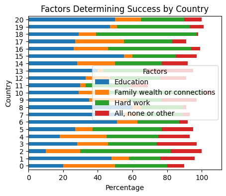

```python
# Plot the horizontal stacked bar graph
ax = df[['Education', 'Family wealth or connections', 'Hard work', 'All, none or other']].plot(kind='barh', stacked=True, figsize=(5, 4))

# Set the title and labels
ax.set_title('Factors Determining Success by Country')
ax.set_xlabel('Percentage')
ax.set_ylabel('Country')

# Display the legend
ax.legend(title='Factors')

# Show the plot
plt.show()
```

In this Markdown cell, list the changes that need to be made to the default stacked bar graph to make it look like the one above.  
Note why the change should be made. I did the first one for you.

1. Reorder the countries based on gross national income per capita. This will add logic to the y-axis ordering.
2. Change from a **stacked bar chart** to **separate grouped subplots** (one for each factor).  
   *This makes it easier to directly compare Education, Hard Work, Family Wealth, and Other across countries.*
3. Use **country names** on the y-axis instead of numbers.  
   *This makes the chart meaningful and readable without needing a separate key.*
4. Apply a **muted, consistent color palette** (e.g., blue, green, purple, gold).  
   *Improves readability and professionalism compared to bright stacked colors.*
5. Move the **legend into column titles** (Education, Hard Work, etc.).  
   *Reduces clutter and makes interpretation faster.*
6. Add **vertical reference lines** at 25% and 50%.  
   *Helps the reader visually estimate values by lining them up across countries.*
7. Add **horizontal grid lines** for each country.  
   *Makes it easier to track a country’s row across all four factors.*
8. Adjust the **x-axis ticks** to show only 0%, 25%, 50%, and 75%.  
   *Keeps focus on the relevant range while aligning cleanly across all subplots.*
9. Left-align the **main title** and add a **subtitle**.  
   *Matches the style of professional reports and provides context for the data.*
10. Include a **footnote note at the bottom** with the data source and GNI explanation.  
    *Gives credibility and transparency to the visualization.*

Now create the improved graph.

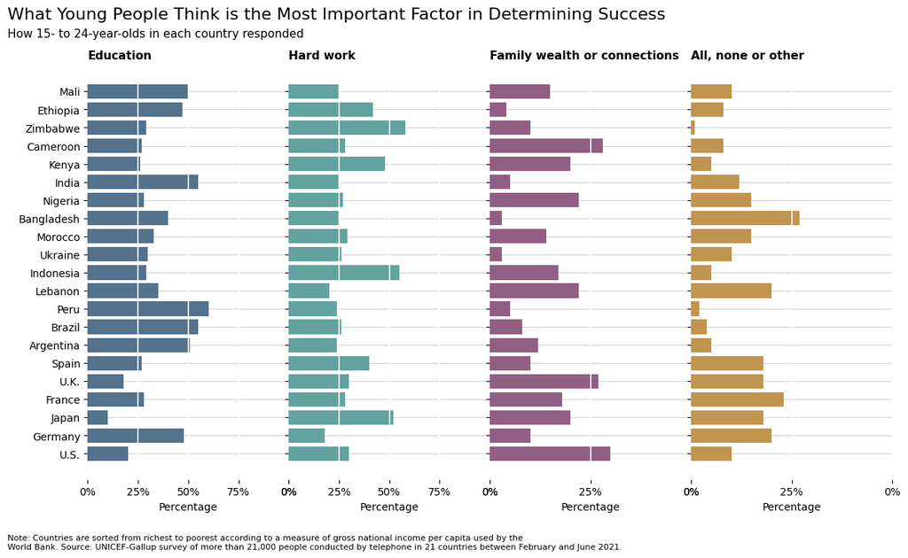

```python
import pandas as pd
import matplotlib.pyplot as plt

# Your dataset
data = {
    'Country': ['U.S.', 'Germany', 'Japan', 'France', 'U.K.', 'Spain', 'Argentina', 'Brazil', 'Peru', 'Lebanon',
                'Indonesia', 'Ukraine', 'Morocco', 'Bangladesh', 'Nigeria', 'India', 'Kenya', 'Cameroon', 'Zimbabwe',
                'Ethiopia', 'Mali'],
    'Education': [20, 48, 10, 28, 18, 27, 51, 55, 60, 35, 29, 30, 33, 40, 28, 55, 26, 27, 29, 47, 50],
    'Hard work': [30, 18, 52, 28, 30, 40, 24, 26, 24, 20, 55, 26, 29, 25, 27, 25, 48, 28, 58, 42, 25],
    'Family wealth or connections': [30, 10, 20, 18, 27, 10, 12, 8, 5, 22, 17, 3, 14, 3, 22, 5, 20, 28, 10, 4, 15],
    'All, none or other': [10, 20, 18, 23, 18, 18, 5, 4, 2, 20, 5, 10, 15, 27, 15, 12, 5, 8, 1, 8, 10],
    'gni_per_capita': [65000, 48000, 42000, 41000, 40000, 32000, 20000, 15000, 13000, 12000,
                       11000, 9000, 8000, 7000, 6000, 5000, 4000, 3000, 2000, 1000, 500]
}
df = pd.DataFrame(data)

# Sort countries by GNI (richest to poorest)
df = df.sort_values("gni_per_capita", ascending=False)

# Set countries as index so they appear on y-axis
df = df.set_index("Country")

# Choose factor columns
factors = ['Education', 'Hard work', 'Family wealth or connections', 'All, none or other']
colors = ['#54728C', '#62A39F', '#915F84', '#C09550']

# Make subplots (no gaps between them)
fig, axes = plt.subplots(ncols=4, sharey=True, figsize=(12, 7), gridspec_kw={'wspace': 0})

for ax, factor, color in zip(axes, factors, colors):
    ax.barh(df.index, df[factor], color=color)

    # Bolded subplot titles
    ax.set_title(factor, fontsize=11, loc='left', weight='bold')

    # Different x-axis ranges depending on the factor
    if factor in ["Family wealth or connections", "All, none or other"]:
        ax.set_xlim(0, 50)   # only need up to 50%
        ax.set_xticks([0, 25, 50])
        ax.set_xticklabels(["0%", "25%", "0%"])
    else:
        ax.set_xlim(0, 100)  # keep full width for Education and Hard work
        ax.set_xticks([0, 25, 50, 75, 100])
        ax.set_xticklabels(["0%", "25%", "50%", "75%", "0%"])

    # Remove default x-axis grid
    ax.grid(False)

    # Draw vertical white lines ON TOP of bars
    for xpos in ([25, 50] if factor in ["Family wealth or connections", "All, none or other"] else [25, 50, 75]):
        ax.axvline(x=xpos, color="white", linewidth=1.2, zorder=5)

    # Horizontal gray lines for each country
    ax.yaxis.grid(True, color="lightgray", linewidth=0.8)
    ax.set_axisbelow(True)

    # Clean up spines
    for spine in ax.spines.values():
        spine.set_visible(False)


# Keep country names visible on the y-axis
axes[0].set_ylabel("")
axes[0].set_xlabel("Percentage")
for ax in axes[1:]:
    ax.set_ylabel("")
    ax.set_xlabel("Percentage")

# Main title (left aligned) + subtitle
fig.text(0.0, 0.98,
         "What Young People Think is the Most Important Factor in Determining Success",
         fontsize=16, ha="left", va="top")
fig.text(0.0, 0.94,
         "How 15- to 24-year-olds in each country responded",
         fontsize=11, ha="left", va="top")

# Sub text (multi-line paragraph at bottom)
fig.text(0.0, -0.02,
        "Note: Countries are sorted from richest to poorest according to a measure of gross national income per capita used by the\n"
        "World Bank. Source: UNICEF-Gallup survey of more than 21,000 people conducted by telephone in 21 countries between February and June 2021.",
        fontsize=8, ha="left", va="top")

plt.tight_layout(rect=[0, 0, 1, 0.92])
plt.show()
```

Rubric:  
4 points for listing the majority of items that need to changed and why.  
7 points for listing the majority of items that need to changed and why AND getting most of the changes correct in the graph.  
10 points for listing at least 10 items that need to be changed and why AND getting all of the changes correct in the graph.

### Problem #2

*10 points*

Create the bar graph below. Then explain how the scaffolding of the graph helps to tell a story.

[figure not shown]

Data:

```python
data = {
    "Term Start": [1917, 1919, 1921, 1923, 1925, 1927, 1929, 1931, 1933, 1935, 1937, 1939, 1941, 1943, 1945, 1947, 1949, 1951, 1953, 1955, 1957, 1959, 1961, 1963, 1965, 1967, 1969, 1971, 1973, 1975, 1977, 1979, 1981, 1983, 1985, 1987, 1989, 1991, 1993, 1995, 1997, 1999, 2001, 2003, 2005, 2007, 2009, 2011, 2013, 2015, 2017],
    "Term End": [1919, 1921, 1923, 1925, 1927, 1929, 1931, 1933, 1935, 1937, 1939, 1941, 1943, 1945, 1947, 1949, 1951, 1953, 1955, 1957, 1959, 1961, 1963, 1965, 1967, 1969, 1971, 1973, 1975, 1977, 1979, 1981, 1983, 1985, 1987, 1989, 1991, 1993, 1995, 1997, 1999, 2001, 2003, 2005, 2007, 2009, 2011, 2013, 2015, 2017, 2019],
    "Women Representatives": [1, 1, 4, 2, 3, 5, 9, 8, 8, 6, 6, 9, 9, 9, 10, 10, 9, 10, 11, 17, 16, 16, 17, 12, 11, 11, 10, 13, 16, 19, 18, 16, 22, 22, 23, 24, 29, 32, 48, 50, 55, 58, 60, 62, 66, 74, 77, 73, 79, 84, 89],
    "Total Representatives": [435] * 51
}

df = pd.DataFrame(data)
```

Build the bar graph below:

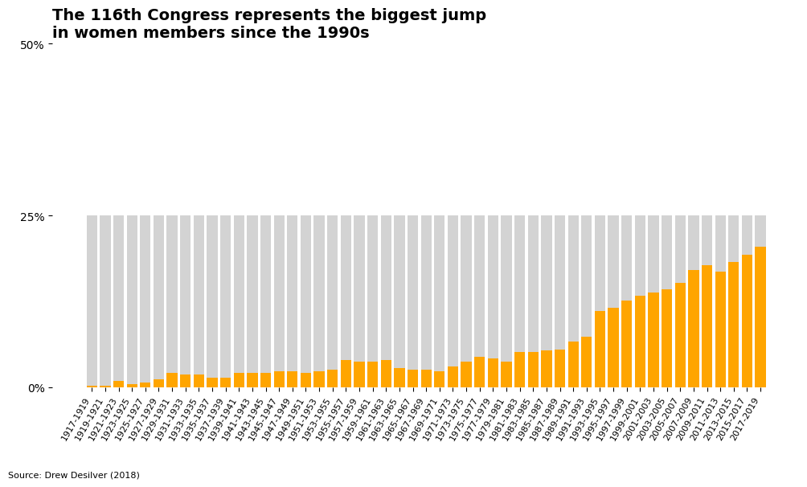

```python
import pandas as pd
import matplotlib.pyplot as plt

# Your dataset
data = {
    "Term Start": [1917, 1919, 1921, 1923, 1925, 1927, 1929, 1931, 1933, 1935, 1937, 1939, 1941, 1943, 1945, 1947, 1949, 1951, 1953, 1955, 1957, 1959, 1961, 1963, 1965, 1967, 1969, 1971, 1973, 1975, 1977, 1979, 1981, 1983, 1985, 1987, 1989, 1991, 1993, 1995, 1997, 1999, 2001, 2003, 2005, 2007, 2009, 2011, 2013, 2015, 2017],
    "Term End": [1919, 1921, 1923, 1925, 1927, 1929, 1931, 1933, 1935, 1937, 1939, 1941, 1943, 1945, 1947, 1949, 1951, 1953, 1955, 1957, 1959, 1961, 1963, 1965, 1967, 1969, 1971, 1973, 1975, 1977, 1979, 1981, 1983, 1985, 1987, 1989, 1991, 1993, 1995, 1997, 1999, 2001, 2003, 2005, 2007, 2009, 2011, 2013, 2015, 2017, 2019],
    "Women Representatives": [1, 1, 4, 2, 3, 5, 9, 8, 8, 6, 6, 9, 9, 9, 10, 10, 9, 10, 11, 17, 16, 16, 17, 12, 11, 11, 10, 13, 16, 19, 18, 16, 22, 22, 23, 24, 29, 32, 48, 50, 55, 58, 60, 62, 66, 74, 77, 73, 79, 84, 89],
    "Total Representatives": [435] * 51
}
df = pd.DataFrame(data)

# Calculate percentage of women
df["Percent Women"] = df["Women Representatives"] / df["Total Representatives"] * 100

# X labels: "start-end"
df["Term"] = df["Term Start"].astype(str) + "-" + df["Term End"].astype(str)

# Plot
fig, ax = plt.subplots(figsize=(10,6))

# Background gray bars (up to 25%)
ax.bar(df["Term"], [25]*len(df), color="lightgray")

# Orange bars for % women
ax.bar(df["Term"], df["Percent Women"], color="orange")

# Title
ax.set_title("The 116th Congress represents the biggest jump\nin women members since the 1990s",
             fontsize=14, loc="left", weight="bold")

# Y-axis settings
ax.set_ylim(0, 50)
ax.set_yticks([0, 25, 50])
ax.set_yticklabels(["0%", "25%", "50%"])

# X-axis settings
ax.set_xticks(range(len(df)))
ax.set_xticklabels(df["Term"], rotation=60, ha="right", fontsize=8)

# Remove chart spines
for spine in ["top","right","left","bottom"]:
    ax.spines[spine].set_visible(False)

# Source note
fig.text(0.0, -0.05, "Source: Drew Desilver (2018)", fontsize=8, ha="left")

plt.tight_layout(rect=[0,0,1,0.95])
plt.show()
```

In this markdown cell, explain how the scaffolding of the graph helps to tell a story (including subtext).

How the scaffolding of the graph tells a story

1. Gray background bars capped at 25%
- The background scaffolding sets a reference ceiling that makes the orange bars look small and struggling for most of the timeline.
- This visual contrast emphasizes how few women were in Congress for much of U.S. history.
- By stopping the gray scaffolding at 25%, the graph visually reinforces the idea that even today, representation remains below parity (50%).
2. Orange bars layered in front
- The bold orange color stands out against the muted gray scaffolding.
- This layering creates a story of change over time, with each orange bar climbing higher and encroaching on the gray background.
3. Left-aligned, bold title
- The title is phrased as a claim: “The 116th Congress represents the biggest jump in women members since the 1990s.”
- This scaffolds the viewer’s interpretation, pointing attention specifically to the recent spike, rather than the entire timeline.
4. Y-axis labeled at 0%, 25%, and 50%
- The limited tick marks help readers quickly situate progress relative to parity.
- Having 50% visible but unattainable in the data adds subtext: even the historic 116th Congress is still far from equal representation.
5. X-axis with detailed term labels
- The rotated two-year term labels provide historical scaffolding, grounding the story in nearly a century of U.S. politics.
- The density of labels also signals continuity and slow change — until the sharp rise in recent decades.
6. Source note at the bottom
- The small citation to Drew Desilver (2018) signals credibility and transparency.
- This scaffolding reminds the reader that the graph is part of a larger narrative built on evidence.

Subtext

The scaffolding of the chart subtly conveys two messages:

- Historical inertia: The long stretch of small orange bars against a flat gray ceiling underscores how little changed for most of the 20th century.
- Recent acceleration, but unfinished story: The steep rise in the last few decades visually dramatizes progress, but the 50% tick mark looms above, reminding viewers that equality has not yet been achieved.

Rubric:  
4 points for getting the discussion points  
7 points for getting the discussion points AND the data on the graph AND the basic structure of the graph.  
10 points for getting the discussion points AND the data on the graph AND all the scaffolding of the graph shown in the example.